# Лабораторная 7

Эффективность рекламы

Шалыгин Г. Э.

Российский университет дружбы народов, Москва, Россия

# Информация

## Докладчик

- Шалыгин Георгий Эдуардович
- студент НФИ-02-20
- Российский университет дружбы народов

# Вводная часть

## Актуальность

- Математическое моделирование - важная часть компетенции в образовательном треке НФИ

## Цели и задачи

- Изучить построение математической эффективности рекламы.
- Задачи:
  - Постройте график распространения рекламы, математическая модель в 3х случаях которой описывается тремя уравнениями.
  2. Для случая 2 определите в какой момент времени скорость распространения рекламы будет иметь максимальное значение.

## Материалы и методы

- Процессор `pandoc` для входного формата Markdown
- Результирующие форматы
  - `pdf`
  - `html`
- Автоматизация процесса создания: `Makefile`
- Компилятор Julia
- OpenModelica

## Содержание исследования

Модель рекламной кампании описывается следующими величинами. Считаем, что $\dfrac{dn}{dt}$ - скорость изменения со временем числа потребителей, узнавших о товаре и готовых его купить, *t* - время, прошедшее с начала рекламной кампании, *n*(*t*) - число уже информированных клиентов. Эта величина пропорциональна числу покупателей, еще не знающих о нем, это описывается следующим образом: *α*<sub>1</sub>(*t*)(*N*−*n*(*t*)) , где *N* - общее число потенциальных платежеспособных покупателей, *α*<sub>1</sub>(*t*) - характеризует интенсивность рекламной кампании (зависит от затрат на рекламу в данный момент времени).

## Содержание исследования

Помимо этого, узнавшие о товаре потребители также распространяют полученную информацию среди потенциальных покупателей, не знающих о нем (в этом случае работает т.н. сарафанное радио). Этот вклад в рекламу описывается величиной *α*<sub>2</sub>(*t*)*n*(*t*)(*N*−*n*(*t*)) , эта величина увеличивается с увеличением потребителей узнавших о товаре. Математическая модель распространения рекламы описывается уравнением:

$$\dfrac{dn}{dt} = (\alpha_1(t)+\alpha_2(t)n(t))(N-n(t))$$

# Результаты

## Модель 1

Вариант 27. Объем аудитории *N* = 756, в начальный момент о товаре знает 17 человек. Рассмотрим первую модель $\dfrac{dn}{dt} = (\alpha_1 + \alpha_2 n(t))(N-n(t))$.

## Случай *α*<sub>1</sub> > > *α*<sub>2</sub>

*a**l**p**h**a*<sub>1</sub> = 0.73, *α*<sub>2</sub> = 0.000013

Модель стремится к модели Мальтуса.

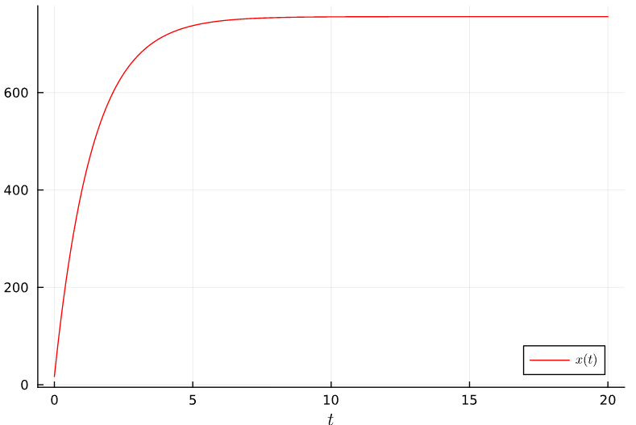

модель 1

## Случай *α*<sub>1</sub> < < *α*<sub>2</sub>

*a**l**p**h**a*<sub>1</sub> = 0.000013, *α*<sub>2</sub> = 0.73

Модель стремится к логистической кривой.

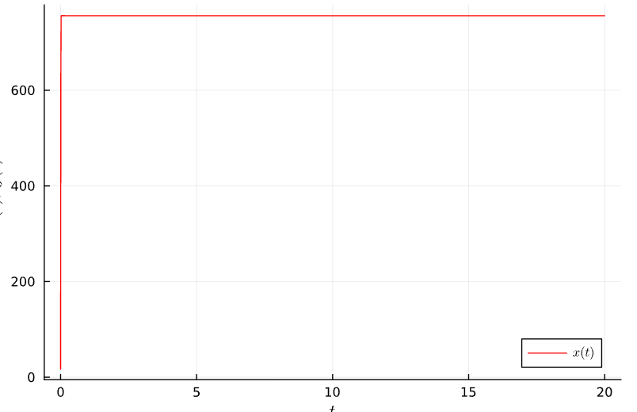

модель 1

## Случай переменных *α*<sub>1</sub>, *α*<sub>2</sub>

Так же видим логистическую кривую.

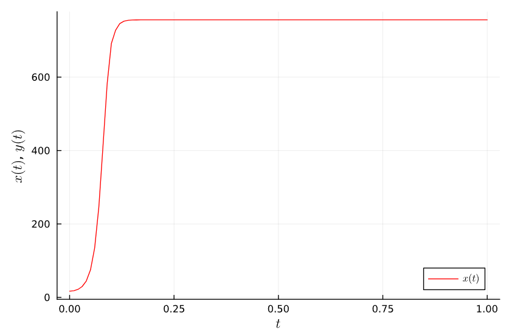

Результаты

# Вывод